# Plastic Debris

Stuart Watt

# Introduction and Setup

I’m using the following packages:

```r
library(tidyverse)
library(purrr)
library(magrittr)
library(treemap)
library(mapdata)
library(viridis)
```

Logged marine debris is available for download [here](http://marinedebris.engr.uga.edu/newmap/). I’m importing data from 2010 till Feb 19th 2020. There doesn’t seem to be data before 2010. The data is reported marine debris.

```r
data <- list.files(path = "data/", full.names = TRUE) %>%
  lapply(FUN = read_csv, col_types = "ififidddddcfcif") %>%
  reduce(rbind)
```

A quick look at the data:

```r
data
```

```
## # A tibble: 363,368 x 15
##    ListID ListName ItemID ItemName LogID Latitude Longitude Altitude Quantity
##     <int> <fct>     <int> <fct>    <int>    <dbl>     <dbl>    <dbl>    <dbl>
##  1     22 Marine …    183 Lumber/…   322     28.0     -82.8     -8.8        1
##  2     22 Marine …    183 Lumber/…   323     28.0     -82.8     -8.7        1
##  3     22 Marine …    187 Cigaret…   324     28.0     -82.8      0.2        2
##  4     22 Marine …    181 Bottle …   325     28.0     -82.8      0.4        1
##  5     22 Marine …    181 Bottle …   326     28.0     -82.8      0.4        1
##  6     22 Marine …    181 Bottle …   327     28.0     -82.8      1.4        1
##  7     22 Marine …    174 Aerosol…   328     28.0     -82.8      1.9        1
##  8     22 Marine …    207 Straws     329     28.0     -82.8      2.6        1
##  9     22 Marine …    185 Disposa…   330     28.0     -82.8      2          1
## 10     22 Marine …    202 Plastic…   331     28.0     -82.8      3          1
## # … with 363,358 more rows, and 6 more variables: `Error Radius` <dbl>,
## #   Timestamp <chr>, Location <fct>, Description <chr>, `Material ID` <int>,
## #   `Material Description` <fct>
```

# Exploratory Data Analysis

Let’s first check for missing values:

```r
data %>% select_if(function(x) any(is.na(x))) %>% colnames()
```

```
## [1] "Location"    "Description"
```

So only these columns contain missing values. We will use an explicit missing value for the location factor:

```r
data$Location <- data$Location %>% fct_explicit_na()
```

Lets see the amount of unique values for each column:

```r
data %>% apply(2, function(x) length(unique(x)))
```

```
##               ListID             ListName               ItemID
##                    1                    1                   55
##             ItemName                LogID             Latitude
##                   55               363368               142707
##            Longitude             Altitude             Quantity
##               136490               135214                  496
##         Error Radius            Timestamp             Location
##                18374               248436                 1458
##          Description          Material ID Material Description
##                 8494                    8                    8
```

Both “ListID” and “ListName” don’t give us any information, so we will remove them both.

```r
data <- data %>% select(-ListID,-ListName)
```

Lets see if there are any “ItemNames” associated with more than one “Material Descriptions”.

```r
data %>% select(`Material Description`, ItemName) %>%
  distinct() %$%
  table(ItemName) %>%
  as_tibble() %>%
  filter(n > 1)
```

```
## # A tibble: 1 x 2
##   ItemName          n
##   <chr>         <int>
## 1 Rubber Gloves     2
```

So rubber gloves are associated with two material descriptions, but otherwise a one to many relationship exists between “Material Description” and “ItemName”.

```r
data %>% select(`Material Description`, ItemName, Quantity) %>%
  filter(ItemName == "Rubber Gloves") %>%
  group_by(`Material Description`) %>%
  summarise(Quantity = sum(Quantity))
```

```
## # A tibble: 2 x 2
##   `Material Description` Quantity
##   <fct>                     <dbl>
## 1 PLASTIC                    2114
## 2 RUBBER                      155
```

It seems that most rubber gloves are classified as plastic rather than rubber.

```r
data %>% select(`Material Description`, ItemName, Description) %>%
  filter(ItemName == "Rubber Gloves", !is.na(Description)) %>%
  distinct()
```

```
## # A tibble: 18 x 3
##    `Material Description` ItemName     Description
##    <fct>                  <fct>        <chr>
##  1 PLASTIC                Rubber Glov… Found on wassaw island Oct. 21 with beac…
##  2 PLASTIC                Rubber Glov… undefined
##  3 PLASTIC                Rubber Glov… thermal
##  4 PLASTIC                Rubber Glov… Near water
##  5 PLASTIC                Rubber Glov… Taste of Omaha Cleanup
##  6 PLASTIC                Rubber Glov… 2 diff kinds
##  7 PLASTIC                Rubber Glov… Latex
##  8 PLASTIC                Rubber Glov… Hose
##  9 PLASTIC                Rubber Glov… Cap
## 10 PLASTIC                Rubber Glov… Vial
## 11 PLASTIC                Rubber Glov… Gloves
## 12 PLASTIC                Rubber Glov… Black intact
## 13 PLASTIC                Rubber Glov… Clear intact
## 14 PLASTIC                Rubber Glov… White glove fragmented
## 15 PLASTIC                Rubber Glov… Fishing glove
## 16 PLASTIC                Rubber Glov… Rubbery fragments
## 17 PLASTIC                Rubber Glov… Rubber band and fishing bait
## 18 PLASTIC                Rubber Glov… Balloon
```

All non-missing descriptions of rubber gloves are described as plastic.

Distribution of observed debris:

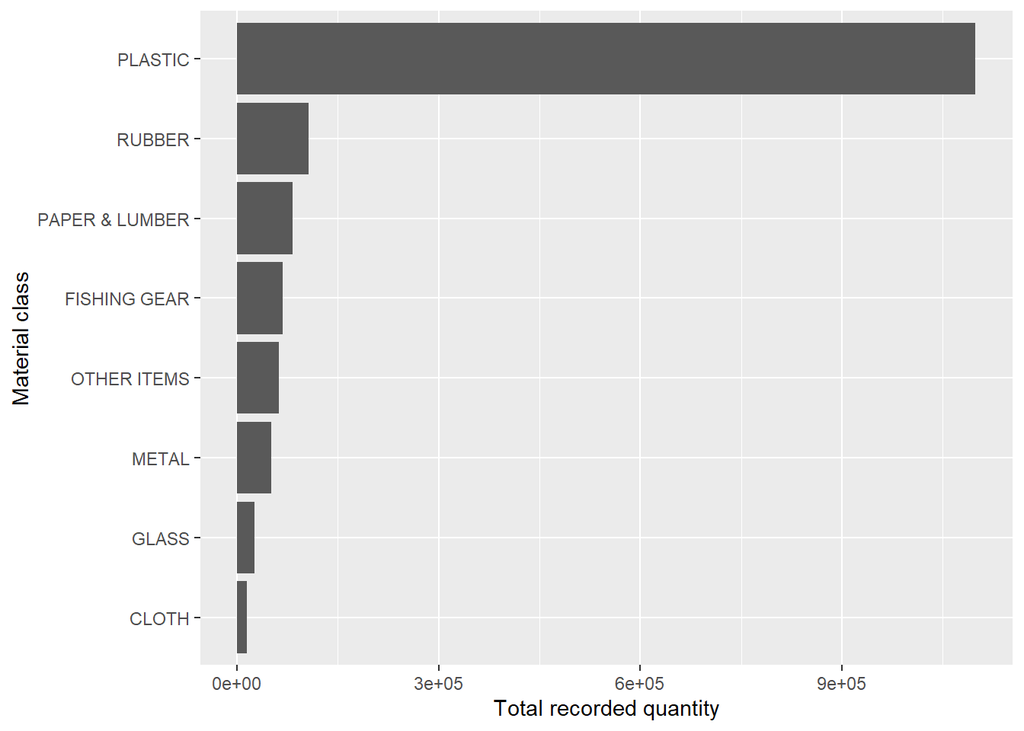

```r
data %>% select(Quantity,Description,`Material Description`) %>%
  group_by(`Material Description`) %>%
  summarise(Quantity = sum(Quantity)) %>%
  ggplot(aes(x = reorder(`Material Description`, Quantity), y = Quantity)) +
    geom_col() +
    ylab("Total recorded quantity") +
    xlab("Material class") +
    coord_flip()
```

A tree map of material quantities:

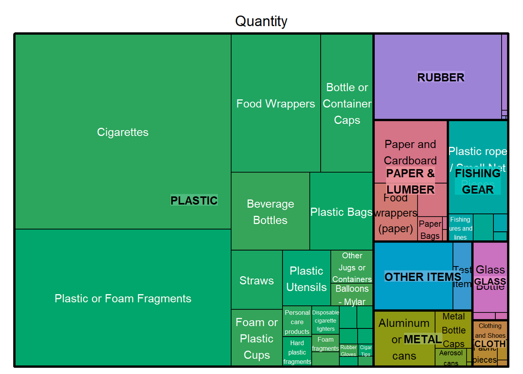

```r
data %>%
  select(`Material Description`, ItemName, Quantity) %>%
  group_by(`Material Description`, ItemName) %>%
  summarise(Quantity = sum(Quantity)) %>%
  treemap(index = c("Material Description", "ItemName"),
          vSize = "Quantity", draw = TRUE)
```

Perhaps some of the debris is not actually from the sea, but rather from people littering by the coastline? Does debris littered on the coastline end up in the oceans?

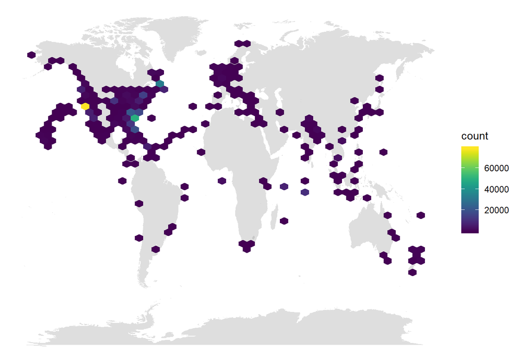

```r
world <- map_data("world")
data %>%
  select(Latitude, Longitude, Quantity, Location, `Material Description`) %>%
  ggplot() +
    geom_polygon(data = map_data("world"), aes(x = long, y = lat, group = group), fill = "grey", alpha = 0.5) +
    geom_hex(aes(x = Longitude, y = Latitude), bins = 50) +
    scale_fill_viridis() +
    theme_void()
```

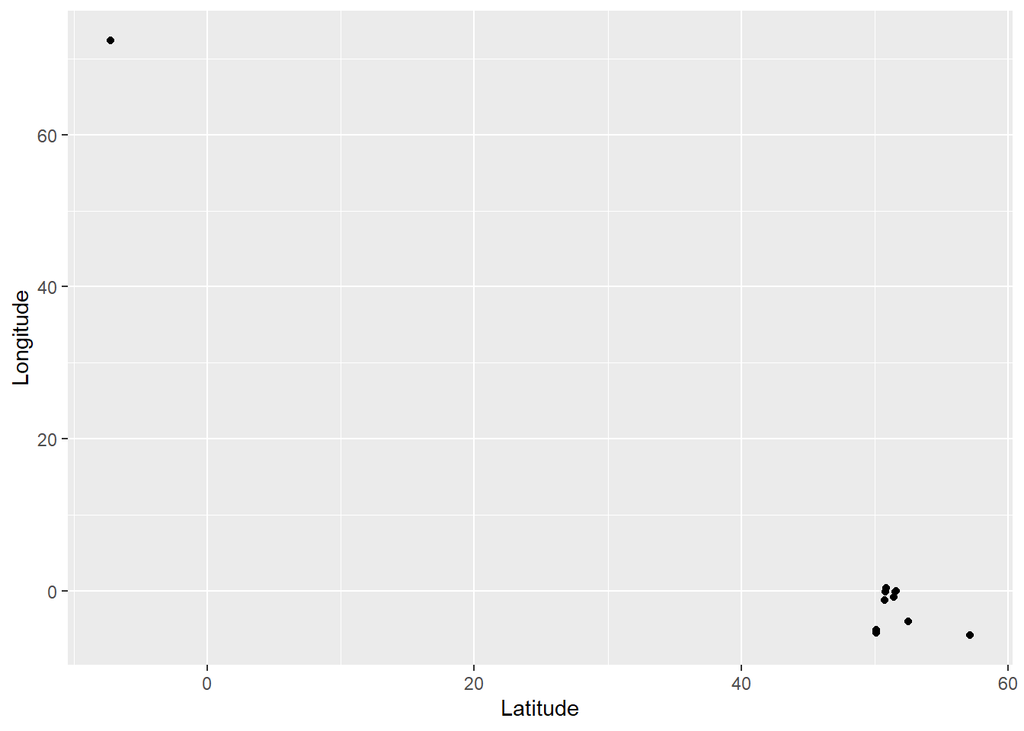

```r
data %>% mutate(Location = str_to_lower(Location)) %>%
  filter(str_detect(Location, "united kingdom")) %>%
  select(Latitude, Longitude) %>%
  ggplot(aes(x = Latitude, y = Longitude)) +
    geom_point()
```

```r
data %>% mutate(Location = str_to_lower(Location)) %>%
  filter(str_detect(Location, "ocean")) %>%
  select(Location) %>%
  distinct()
```

```
## # A tibble: 12 x 1
##    Location
##    <chr>
##  1 ocean city, md
##  2 ocean city, nj
##  3 ocean shores, wa
##  4 ocean park, wa
##  5 ocean pines, md
##  6 ocean ridge, fl
##  7 oceanside, ca
##  8 ocean springs, mississippi, usa
##  9 ocean springs, mississippi, united states
## 10 british indian ocean territory
## 11 ocean bluff-brant rock, massachusetts, united states
## 12 oceana county, michigan, united states of america
```

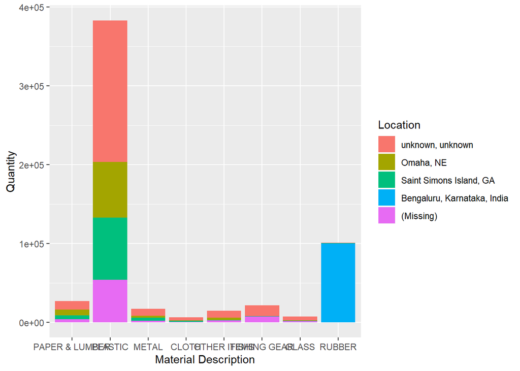

```r
topLocations <- data %>%
  group_by(Location) %>%
  summarise(Quantity = sum(Quantity)) %>%
  arrange(desc(Quantity)) %>%
  top_n(5,Quantity)

data %>%
  filter(Location %in% topLocations$Location) %>%
  group_by(Location, `Material Description`) %>%
  summarise(Quantity = sum(Quantity)) %>%
  arrange(desc(Quantity)) %>%
  ggplot(aes(x = `Material Description`, y = Quantity, fill = Location)) +
    geom_col()
```